# Project 1: Integration of InsertionSort & MergeSort

Har Jing Daryl

Goh Teng Wei

Koh Jun Kai

## Time Complexity of Hybrid Sort

Given n elements to sort, and threshold s

## Merge Portion

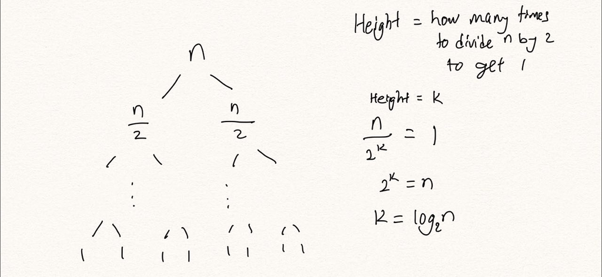

## Merge Portion

Thus in merge sort, we have `log(n)` levels.

In the combined sort, we want to stop when an array has <= s elements. Hence, there are `log(s)` levels left if we stop at threshold s.

Therefore, we go through `log(n) - log(s)` levels for merge sort. `log(n) - log(s) = log(n/s)`

Merge takes `O(n)` comparisons for each level, since it has to go through n elements on average for every merge. Hence, the time complexity for the merge part of the algorithm is O(nlog(n/s)).

## Insertion Portion

For the remaining levels, we have s elements in each array.

In worst case (descending order):

0 + 1 + 2 + ... + (n-1) = (n^2-n)/2

Time Complexity = `O(n^2)`. Analysis of the average case will also result in `O(n^2)` time complexity.

Thus, average/worst case time complexity for insertion sort is `O(n^2)`.

Therefore, the time complexity of sorting the remaining arrays is `O((n/s) * s^2)` = O(ns)

Merge + Insertion = `O(nlog(n/s)+ns)`

### Time complexity of Hybrid Sort is: O(nlog(n/s) + ns)

## Reading data from results

```python
# Read data from results.csv
results = pd.read_csv("results.csv")
results
```

|  | size | sort_type | input_type | micro_time | comparisons |
| --- | --- | --- | --- | --- | --- |
| 0 | 0 | insertion | ascending | 0.741571 | 0.00 |
| 1 | 0 | merge | ascending | 0.749857 | 0.00 |
| 2 | 0 | hybrid | ascending | 0.744000 | 0.00 |
| 3 | 0 | insertion | descending | 0.748714 | 0.00 |
| 4 | 0 | merge | descending | 0.726857 | 0.00 |
| ... | ... | ... | ... | ... | ... |
| 2245 | 249 | merge | descending | 14.939900 | 977.00 |
| 2246 | 249 | hybrid | descending | 12.665700 | 4364.00 |
| 2247 | 249 | insertion | random | 31.871100 | 15667.40 |
| 2248 | 249 | merge | random | 21.960100 | 1670.03 |
| 2249 | 249 | hybrid | random | 19.856300 | 8176.25 |

2250 rows × 5 columns

```python
# Get data without hybrid algo
res_no_hybrid = results[results.sort_type != "hybrid"]
res_no_hybrid
```

|  | size | sort_type | input_type | micro_time | comparisons |
| --- | --- | --- | --- | --- | --- |
| 0 | 0 | insertion | ascending | 0.741571 | 0.00 |
| 1 | 0 | merge | ascending | 0.749857 | 0.00 |
| 3 | 0 | insertion | descending | 0.748714 | 0.00 |
| 4 | 0 | merge | descending | 0.726857 | 0.00 |
| 6 | 0 | insertion | random | 0.756857 | 0.00 |
| ... | ... | ... | ... | ... | ... |
| 2242 | 249 | merge | ascending | 14.376700 | 1008.00 |
| 2244 | 249 | insertion | descending | 59.571900 | 31124.00 |
| 2245 | 249 | merge | descending | 14.939900 | 977.00 |
| 2247 | 249 | insertion | random | 31.871100 | 15667.40 |
| 2248 | 249 | merge | random | 21.960100 | 1670.03 |

1500 rows × 5 columns

## a) Comparing CPU runtimes to determine a suitable S

[figure not shown]

### Checking Ascending array

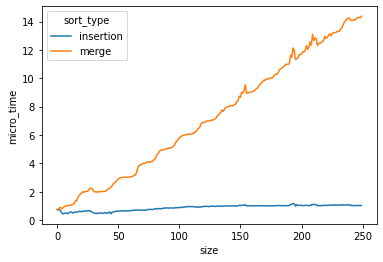

```python
sb.lineplot(data=res_no_hybrid[res_no_hybrid.input_type == "ascending"],
           x="size", y="micro_time", hue="sort_type")
```

Based on the graph, we can see that for **ascending** data, **Insertion Sort runs in constant time**, and is also the most efficient! **S = n** is the best choice.

### Checking Descending array

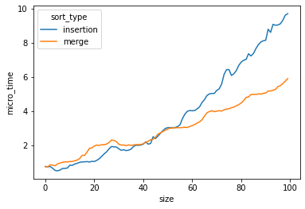

```python
sb.lineplot(data=res_no_hybrid[res_no_hybrid.input_type == "descending"][:200],
            x="size", y="micro_time", hue="sort_type")
```

Based on the graph, we can see that for **descending** data, the threshold S would most likely be **~35-55**.

### Checking Random array

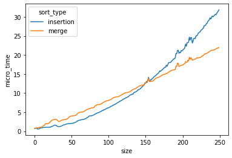

```python
sb.lineplot(data=res_no_hybrid[res_no_hybrid.input_type == "random"],
            x="size", y="micro_time", hue="sort_type")
```

Based on the graph, we can see that for **random** data, the threshold S would most likely be **~150-170**.

### So what is the optimal S?

Simply put, if we know that the array we are getting is going to be more or less sorted, **we use a bigger value for S**.

If we know the array is not very sorted (descending in the worst case), **we use a smaller S**.

This makes sense, as:

1. Insertion Sort "short circuits" comparisons for sorted portions of the array, leading to less time taken.
2. Merge Sort is faster for unsorted portions than Insertion Sort.

### Why not use math to find S?

You can, but it will not be accurate (which our experimental data clearly shows), because it does not take into account real-world issues, such as:

1. Recursion overhead.
2. Element comparisons.
3. Copying memory data. etc...

If we run our algorithm again, and on different machines, we would probably get a different `S` each time!

## b) Merge vs Hybrid Sort

### Checking Ascending array

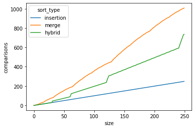

```python
sb.lineplot(data=results[results.input_type == "ascending"],
            x="size", y="comparisons", hue="sort_type")
```

In the best case, we can see **Insertion Sort making O(n) comparisons**.

**Merge Sort continues its divide-and-conquer approach** (and so does **Hybrid Sort**), which results in more comparisons, but **Hybrid Sort makes less comparisons to Merge Sort** as it implements insertion under a certain threshold (which in this case we have decided on as 30).

For the sharp increase in key comparison after the size reaches a multiple of the previous threshold value,

**(2<sup>i</sup>)*S** , for i = natural numbers,

It is because the merge sort algorithm has to be called **2<sup>i-1</sup> more time (2<sup>i</sup> = size n/threshold S)** over the next **2<sup>i</sup>** increase in size, to split the array into a size that is less than the threshold value, therefore increasing the number of key comparisons significantly for merge sort in a short span and hence the hybrid sort.

### Checking Descending array

Based on the result in part (a), we know that the threshold we should set for **descending** ordered arrays should be around 35-55.

In this case, we use **35** as the threshold.

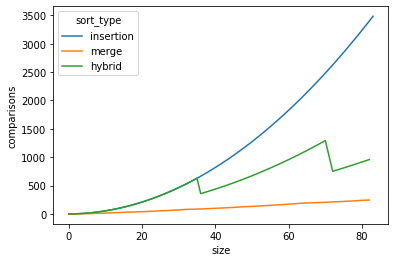

```python
sb.lineplot(data=results[results.input_type == "descending"][:250],
            x="size", y="comparisons", hue="sort_type")
```

We can see that the **Hybrid Sort** follows the **same number of comparisons as Insertion Sort** until the threshold.

For the sharp decrease in key comparison after the size reaches a multiple of the previous threshold value **(2<sup>i</sup>)*S** , for i = natural numbers, it is similar to the reason for the ascending array.

The merge sort algorithm has to be called **2<sup>i-1</sup> more time (2<sup>i</sup> = size n/threshold S)** over the next **2<sup>i</sup>** increase in size, to split the array into a size that is less than the threshold value, which will be essentially **half the size of the threshold**.

This decreases the number of elements for the insertion sort, which will reduce the number of key comparisons significantly as **a descending array is the worst case for insertion sort**. This in turn decreases the key comparisons for the hybrid sort.

### Checking Random array

Based on the result in part (a), we know that the threshold we should set for **random** ordered arrays should be around 150-170.

In this case, we use **165** as the threshold.

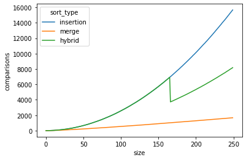

```python
sb.lineplot(data=results[results.input_type == "random"],
            x="size", y="comparisons", hue="sort_type")
```

Likewise, we see **Hybrid Sort** following the same number of comparisons as Insertion Sort until the threshold.

### Notes regarding number of comparisons

In all cases (except ascending order), we can see that **Insertion Sort** makes more comparisons than either **Merge Sort** or **Hybrid Sort**.

## Using results of study (comparing Merge vs Hybrid Sort runtimes)

Now that we know the thresholds required, let us take a look at the timings for **Hybrid Sort** for **random** ordered arrays, using a good guess for the threshold.

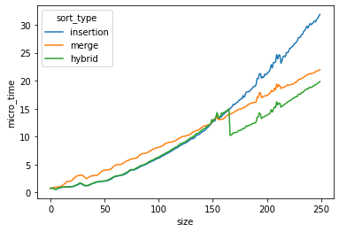

```python
sb.lineplot(data=results[results.input_type == "random"],
            x="size", y="micro_time", hue="sort_type")
```

For **random** ordered arrays, we can see that **Hybrid Sort** is able to achieve lower runtimes than a **pure Merge Sort** by setting a good guess for a threshold (in this case, it is 165 for random).